# 과제1

### 2018111373 최인렬

## 파이썬 파일 설정

```python
import pandas as pd
import numpy as np
import matplotlib.pyplot as plt
```

```python
import matplotlib.pyplot as plt
import matplotlib.font_manager as fm
import matplotlib as mpl
mpl.rcParams['axes.unicode_minus'] = False
mpl.rcParams['font.family'] = 'appleGothic'
mpl.rcParams['font.size'] = 10
```

# 1번

문제 : $\beta_1 = 2$, $\beta_2 = 2$, $s = 12$일 때, 아래의 주어진 식을 참고해서 다음 문제를 풀이하시오.

$$ \begin{aligned} A~\sin\bigg(\frac{2\pi}{s}t + \phi \bigg) &= A~\sin \bigg(\frac{2\pi}{s}t\bigg) \cos(\phi) + A~\cos \bigg(\frac{2\pi}{s}t\bigg) \sin(\phi) \\[10pt] &= \beta_1~\sin \bigg(\frac{2\pi}{s}t\bigg) + \beta_2~\cos\bigg(\frac{2\pi}{s}t\bigg) \end{aligned} $$

## 1-1번. 그래프 그리기

$y = \beta_1~ \sin\big(\frac{2\pi}{s}t\big)$ 와 $y = \beta_2~ \cos\big(\frac{2\pi}{s}t\big)$ 의 그래프 겹쳐 그리기

1. 먼저, 시간대(변수 t)의 범위를 정한다. 여기서는 시작 값을 $0.4 \times \pi$, 끝 값을 $200$으로 정했다.  
   (특별한 이유는 없음)
2. $\beta_1 = 2$ , $\beta_2 = 2$ 이므로 이에 맞게 그래프를 그린다.
3. 또한, $\beta_1 = 2$, $\beta_2 = 2$, $s = 12$ 도 변수로 넣는다.
- $y = \beta_1~sin\big(\frac{2\pi}{s}t\big)$를 y1이라고 명명.
- $y = \beta_2~cos\big(\frac{2\pi}{s}t\big)$를 y2라고 명명

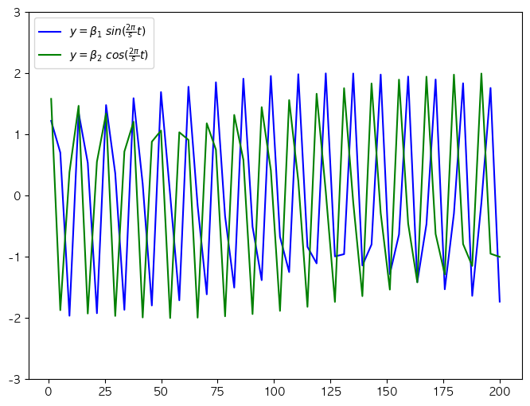

```python
beta1 = 2; beta2 = 2; s = 12

t = np.linspace(0.4 * np.pi, 200)
y1 = beta1 * np.sin((2 * np.pi * t) / s)
y2 = beta2 * np.cos((2 * np.pi * t) / s)

label_y1 = r'$y = \beta_1~sin(\frac{2\pi}{s}t)$'
label_y2 = r'$y = \beta_2~cos(\frac{2\pi}{s}t)$'

plt.figure(figsize=(8, 6))
plt.plot(t, y1, label = label_y1, color='blue')
plt.plot(t, y2, label = label_y2, color='green')
plt.legend(loc='upper left', fontsize = 10)
plt.ylim(-3, 3)
plt.show()
```

## 1-2. A와 $\phi$ 구하기

문제 : 위의 주어진 식을 참고해서 A와 $\phi$를 구해보시오

삼각함수의 덧셈정리를 이용해 우리는 A와 $\phi$를 구해볼 수 있다.

$$ \begin{aligned} \sin(\alpha + \beta) &= \sin(\alpha)~\cos(\beta) ~+~ \cos(\alpha)~\sin(\beta) \\[3pt] \sin(\omega t + \phi) &= \sin(\omega t)~\cos(\phi) ~+~ \cos(\omega t)~\sin(\phi) \\[3pt] A\sin(\omega t+ \phi) &= A~\sin(\omega t)~\cos(\phi) ~+~ A~\cos(\omega t)~\sin(\phi) \\[6pt] \end{aligned} $$

이 공식을 다시 이용해보면...

$$ \begin{aligned} A\sin(\omega t+ \phi) &= A~\cos(\phi)~\sin(\omega t) ~+~ A~sin(\phi)~\cos(\omega t) \\[6pt] &= \beta_1~\sin\bigg(\frac{2\pi}{s}t\bigg) + \beta_2~\cos\bigg(\frac{2\pi}{s}t\bigg) \end{aligned} $$

즉, 우리는 $\beta_1 = A~\cos(\phi) $ 이고, $\beta_2 = A~\sin(\phi)$ 임을 알 수 있다.  
이때, $\beta_2$를 $\beta_1$으로 나눠보면 다음과 같다.

$$ \frac{A~\sin(\phi)}{A~\cos(\phi)} = \tan(\phi) = \frac{\beta_2}{\beta_1} $$

따라서, $\phi$를 구해보면 다음과 같다.

$$ \phi = tan^{-1}\bigg(\frac{\beta_2}{\beta_1}\bigg) $$

또한, $\beta_1$과 $\beta_2$를 제곱해 보면 다음과 같다.

$$ \begin{aligned} {\beta_1}^{2} + {\beta_2}^{2} &= A^2\cos^{2}(\phi) + A^2\sin^{2}(\phi) \\[3pt] &= A^2~\{\cos^{2}(\phi) + \sin^{2}(\phi)\} \\[3pt] &= A^2 \end{aligned} $$

따라서, A를 구해보면 다음과 같다.

$$ A = \sqrt{{\beta_1}^{2} + {\beta_2}^{2}} $$

```python
A = np.sqrt(beta1 * 2 + beta2 * 2)
phi = np.arctan(beta2 / beta1)

print(f"A = {A}\nphi = {phi}")
```

```
A = 2.8284271247461903
phi = 0.7853981633974483
```

따라서 $A \approx 2.828 $ 이고, $\phi \approx 0.785$ 이다.

## 1-3. 그래프 그리고 확인

문제 : $y = A\sin\big(\frac{2\pi}{s}t + \phi \big)$ 그래프를 그린 후,

$y = \beta_1 \sin \big(\frac{2\pi}{s}t\big) + \beta_2 \cos\big(\frac{2\pi}{s}t\big)$ 그래프가 이와 동일한지 확인해보시오.

먼저, $y = A\sin\big(\frac{2\pi}{s}t + \phi \big)$ 그래프를 그린다.

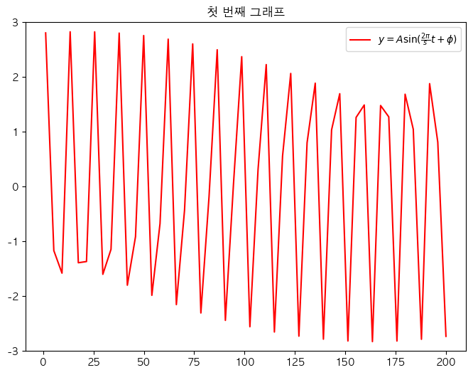

```python
t = np.linspace(0.4 * np.pi, 200)
y3 = A * np.sin(((2 * np.pi * t) / s) + phi)
label_y3 = r'$y = A \sin (\frac{2\pi}{s}t + \phi )$'

plt.figure(figsize=(8, 6))
plt.title("첫 번째 그래프")
plt.plot(t, y3, label = label_y3, color='red')
plt.legend()
plt.ylim(-3, 3)
plt.show()
```

또, $y = \beta_1 \sin \big(\frac{2\pi}{s}t\big) + \beta_2 \cos\big(\frac{2\pi}{s}t\big)$ 그래프를 그려보자

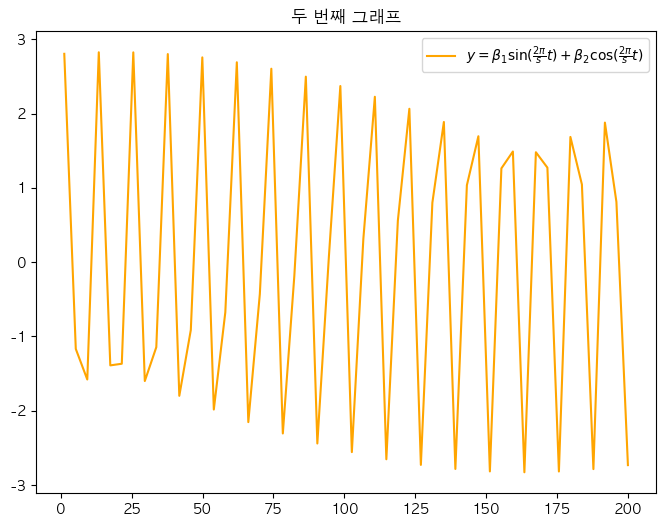

```python
y4 = y1 + y2
label_y4 = r'$y = \beta_1 \sin (\frac{2\pi}{s}t ) + \beta_2 \cos (\frac{2\pi}{s}t)$'

plt.figure(figsize=(8, 6))
plt.title("두 번째 그래프")
plt.plot(t, y4, label = label_y4, color='orange')
plt.legend()
plt.show()
```

인제 둘을 겹쳐서 그려보자.

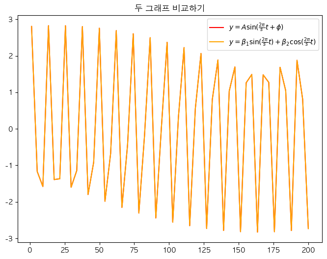

```python
plt.figure(figsize=(8, 6))
plt.plot(t, y3, label = label_y3, color = 'red')
plt.plot(t, y4, label = label_y4, color = 'orange')
plt.title('두 그래프 비교하기')
plt.legend(loc='upper right', fontsize = 10)
plt.show()
```

빨간색과 오랜지색이 섞여나오는 것을 볼 때, 두 그래프의 차이가 없음을 알 수 있다.

# 2번

문제 : $A_1 = 1$, $\phi_1 = 2$이고, 주기가 12인 $A_1 \sin \big(\frac{2\pi}{s}t + \phi_1 \big)$ 그래프와 $A_2 = 2$, $\phi_2 = 1$이고 주기가 6인 $A_2 \sin \big(\frac{2\pi}{s}t + \phi_2 \big)$ 그래프를 각각 그린 후, 두 사인 함수를 더한 그래프를 그리시오.

## 주어진 그래프 그리기

- 시간대 t는 1번에서 쓴 것을 그대로 쓴다.
- $A_1 = 1$ , $\phi_1 = 2$ 이고 주기 $s_1 = 12$ 인 $A_1 \sin \big(\frac{2\pi}{s} t + \phi_1 \big)$ 그래프를 그린다.
- $A_2 = 2$ , $\phi_2 = 1$ 이고 주기 $s_2 = 6$ 인 $A_2 \sin \big(\frac{2\pi}{s} t + \phi_2 \big)$ 그래프를 그린다.

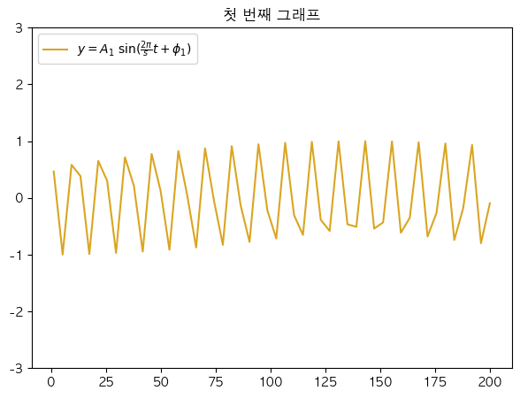

```python
a_1 = 1; phi_1 = 2; s1 = 12
y_1 = a_1 * np.sin((2 * np.pi * t / s1) + phi_1)
label_y_1 = r'$y = A_1~\sin (\frac{2\pi}{s} t + \phi_1 )$'

plt.figure(figsize=(7, 5))
plt.title("첫 번째 그래프")
plt.plot(t, y_1, label = label_y_1, color='goldenrod')
plt.ylim(-3, 3)
plt.legend(loc='upper left')
plt.show()
```

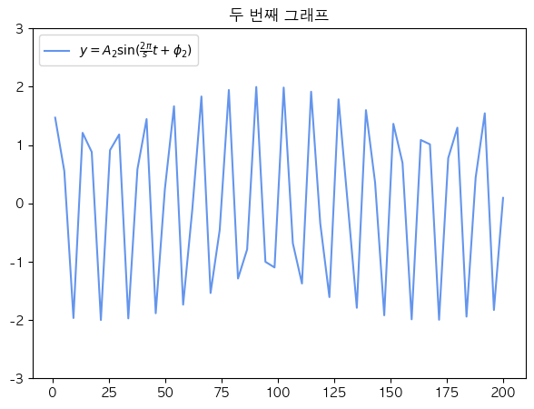

```python
a_2 = 2; phi_2 = 1; s2 = 6
y_2 = a_2 * np.sin((2 * np.pi * t / s2) + phi_2)
label_y_2 = r'$y = A_2 \sin (\frac{2\pi}{s} t + \phi_2 )$'

plt.figure(figsize=(7, 5))
plt.title("두 번째 그래프")
plt.plot(t, y_2, label = label_y_2, color='cornflowerblue')
plt.ylim(-3, 3)
plt.legend(loc='upper left')
plt.show()
```

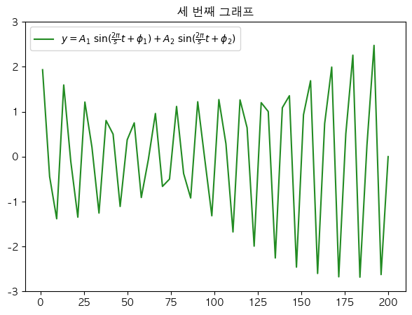

```python
y_3 = y_1 + y_2
label_y_3 = r'$y = A_1~\sin (\frac{2\pi}{s} t + \phi_1 ) + A_2~\sin (\frac{2\pi}{s} t + \phi_2 )$'

plt.figure(figsize=(7, 5))
plt.title("세 번째 그래프")
plt.plot(t, y_3, label = label_y_3, color='forestgreen')
plt.ylim(-3, 3)
plt.legend(loc='upper left')
plt.show()
```

# 3번

- 문제 : `Temperature.csv` 자료를 이용하여 서울시의 5년 간 월별 평균 기온을 분석하고자 한다. 주기를 최대 3개까지 사용하여 모형을 적합시켜 본 후 주기를 몇까지 사용하여 분석하는 것이 적절한지 설명하시오.

```python
# 라이브러리 가지고 오기
from statsmodels.tsa.deterministic import DeterministicProcess
```

## 데이터 불러오기와 EDA

```python
# 데이터 불러오기
data = pd.read_csv('./Temperature.csv')

# 데이터 정리: 연도와 월을 합쳐서 datetime 형식의 인덱스를 만들고, 월별로 정리
data['Date'] = pd.to_datetime(data[['Year', 'Month']].assign(DAY=1))
data.set_index('Date', inplace=True)

# 월별 기온 시계열
monthly_avg_temp = data['Temperature'].resample('ME').mean()
```

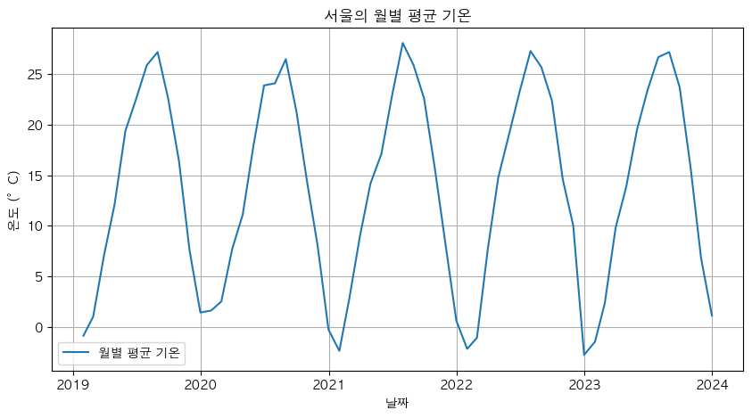

```python
# 시계열 데이터 시각화
plt.figure(figsize=(10, 5))
plt.plot(monthly_avg_temp, label='월별 평균 기온')
plt.title('서울의 월별 평균 기온')
plt.xlabel('날짜')
plt.ylabel('온도 (°C)')
plt.legend()
plt.grid(True)
plt.show()
```

## EDA 결과 및 분석

- sin 항은 2개 정도가 있으면 충분할 것 같음.
- 월별기온이 1년에 따라 반복되고 있음.

## 적합용 함수 & 그래픽 함수 만들기

```python
# 푸리에 급수 기반의 모형 적합 함수 작성
def fit_fourier_series(series, p):
    # 시간 인덱스를 기반으로 푸리에 모형 생성
    dp = DeterministicProcess(
        index=series.index,     # 시간축 (x축)
        constant=True,          # 상수항 여부
        period = p,             # 주기 결정
        fourier = 2             # 사인 항의 갯수
    )

    # 최소제곱법을 사용해 모형 적합
    X = dp.in_sample()  # 훈련 데이터 생성
    y = series.values
    coef = np.linalg.lstsq(X, y, rcond=None)[0]

    # 예측값 계산
    fit = X @ coef
    return fit, coef
```

```python
def draw_graph(fit, period):
    plt.plot(monthly_avg_temp.index, fit, label=f'주기 : {period}')
    plt.plot(monthly_avg_temp, label='원 데이터', color='red', linewidth=2, alpha=0.7)
    plt.title(f'원 데이터 vs 계절추세모형 (주기 : {period})')
    plt.xlabel('날짜')
    plt.ylabel('온도 (`C)')
    plt.legend()
    plt.grid(True)
    plt.show()
```

## 주기별 그래프 적합 결과

- 주기가 11, 12, 13일때 각각 테스트를 진행.

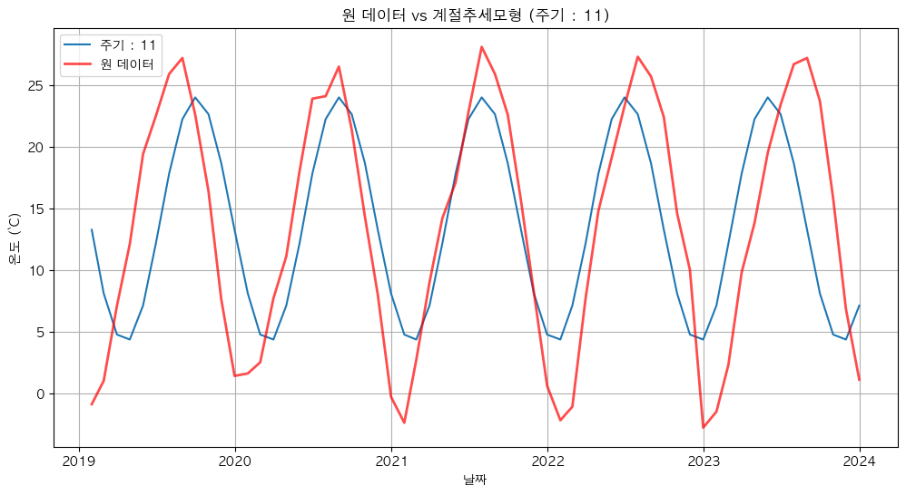

```python
period = 11
plt.figure(figsize=(12, 6))
fit, coef = fit_fourier_series(monthly_avg_temp, period)
draw_graph(fit, period)
```

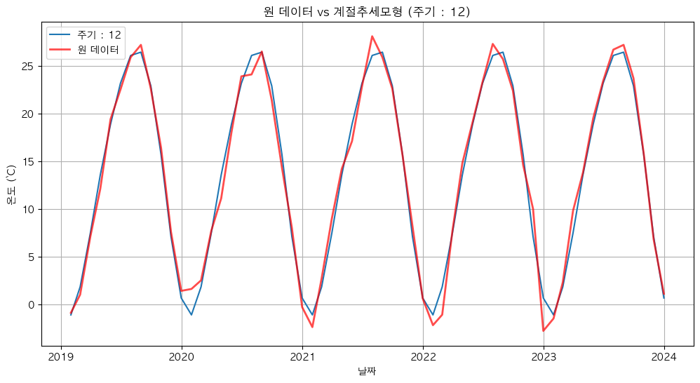

```python
period = 12
plt.figure(figsize=(12, 6))
fit, coef = fit_fourier_series(monthly_avg_temp, period)
draw_graph(fit, period)
```

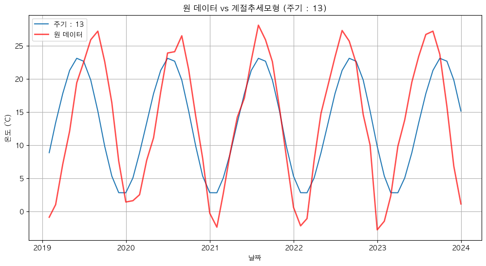

```python
period = 13
plt.figure(figsize=(12, 6))
fit, coef = fit_fourier_series(monthly_avg_temp, period)
draw_graph(fit, period)
```

가장 적합한 것은 주기가 12일때 임을 알 수 있다.